# Task 1: Sierra Amphibians

Michelle Shteyn

1/15/2021

# Overview

For Task 1, I will explore amphibian abundance data collected by Dr. Knapp and colleagues (2020) and recorded by the Sierra Lakes Inventory Project (SLIP). I will:

- Read in data in a .xlsx file
- Do some wrangling
- Create two visualizations and put them together in a finalized compound figure

```r
# Read in a .xlsx file, do some wrangling
frogs <- read_excel(here("data","sierra_amphibians.xlsx")) %>%
  mutate(survey_date = ymd(survey_date)) %>% # Convert date to a stored date class
  mutate(year = year(survey_date)) # Create a new column which extracts year

frogs_grouped <- frogs %>%
  filter(amphibian_life_stage != "EggMass") %>%  #Exclude 'EggMass' observations
  group_by(year, amphibian_life_stage) %>% # Group by year and life stage
  summarize(counts = n()) #Find total counts of frogs in all life stages excluding 'EggMass'
```

## Graph 1

Below, I will create a graph of total mountain yellow-legged frog (Rana muscosa) count each year across all water bodies, by life stage excluding the ‘EggMass’ level.

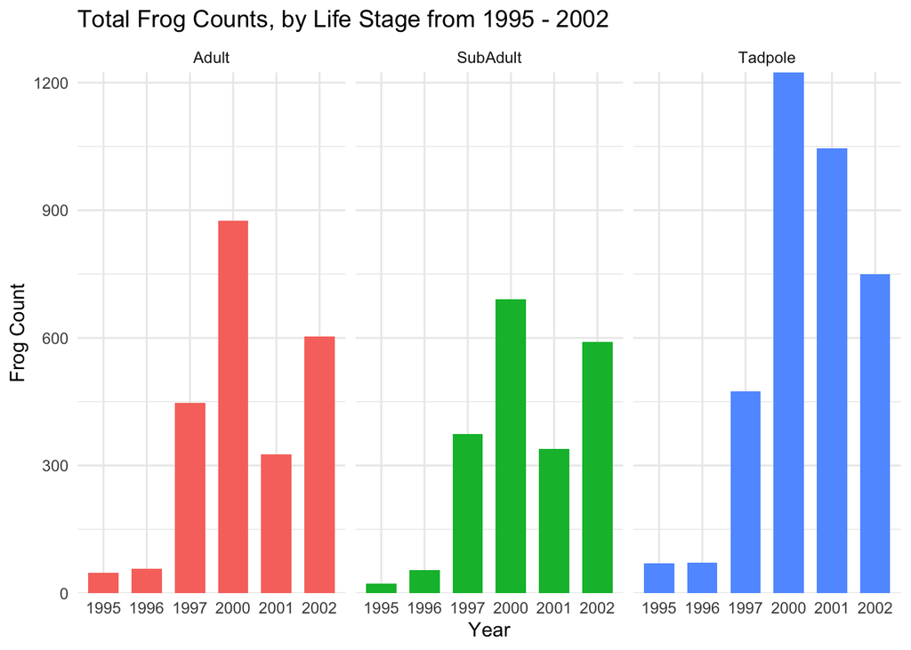

```r
plot_a <- ggplot(data = frogs_grouped, aes(x = as.factor(year), y = counts, fill=amphibian_life_stage))+
  facet_wrap(~amphibian_life_stage)+
  geom_histogram(stat = "identity", width = 0.7, show.legend = FALSE)+
  scale_y_continuous(expand = c(0,0))+
  theme_minimal()+
  labs(x = "Year",
       y = "Frog Count",
       title = "Total Frog Counts, by Life Stage from 1995 - 2002")

plot_a
```

## Graph 2

Below, I will create a column graph containing total counts (over all years of the study) of combined adult and sub-adult endangered mountain yellow-legged frogs observed in the 8 lakes with the greatest total observed counts.

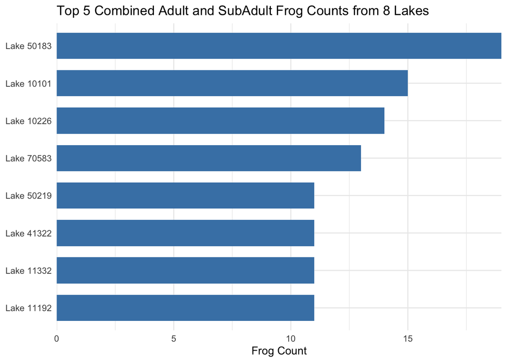

```r
top_5_frog <- frogs %>%
  filter(amphibian_life_stage %in% c("Adult","SubAdult")) %>% # Exclude tadpoles
  mutate(lake_id_txt = sub("","Lake ", lake_id)) %>% # Create a new column which adds 'Lake' in front of lake id number
  mutate(lake_id_txt = fct_reorder(lake_id_txt, lake_id)) %>%
  count(lake_id_txt) %>% # Get counts of total frog in each lake
  rename(frog_count = n) %>%  # Call that column 'frog_count'
  relocate(frog_count) %>% # Change the location of that columns
  slice_max(frog_count, n = 5)  # Keep the 5 Lakes with greatest observed total frog counts

plot_b <- ggplot(data = top_5_frog, aes(x = fct_reorder(lake_id_txt,frog_count), y = frog_count)) +
  geom_col(width = 0.7, fill = "steelblue") +
  labs(y = "Frog Count", x = "Lake ID", title = "Top 5 Combined Adult and SubAdult Frog Counts from 8 Lakes") +
  coord_flip() +
  theme_minimal() +
  theme(axis.title.y = element_blank())+
  scale_y_continuous(expand = c(0,0))

plot_b
```

## Compound Figure

Below, I will combine Graph 1 and Graph 2 into a compound figure using the `patchwork` package.

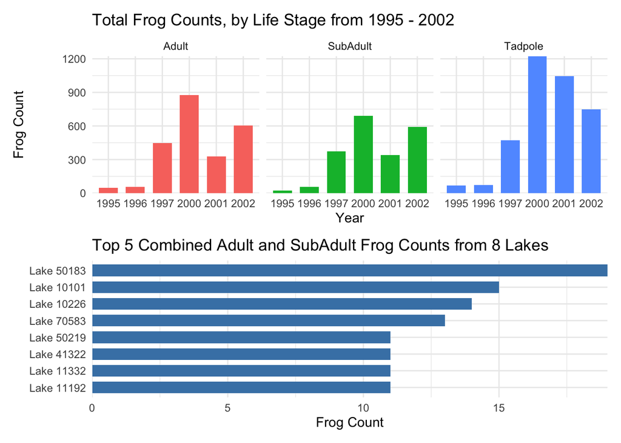

**Figure 1**. This figure contains two graphs of total mountain yellow-legged frogs (*Rana muscosa*): total frog counts by life stage from 1995 to 2002 (top) and top 5 total frog counts of combined adult and sub-adults from the 8 lakes with the greatest observed counts (bottom).This data was recorded by the Sierra Lakes Inventory Project, which ran from 1995-2002 and surveyed aquatic communities for over 8,000 water bodies in the southern Sierra Nevada.

## Data Citation

Knapp, R.A., C. Pavelka, E.E. Hegeman, and T.C. Smith. 2020. The Sierra Lakes Inventory Project: Non-Native fish and community composition of lakes and ponds in the Sierra Nevada, California ver 2. Environmental Data Initiative. https://doi.org/10.6073/pasta/d835832d7fd00d9e4466e44eea87fab3

Click [here](https://drive.google.com/file/d/1OpvnYG2tQ8WfiLKzloeZZD5vtl7wNAdG/view) to download the data.